# **성향점수매칭(PSM)을 통한 음주와 고혈압간 인과효과 추정**

### *작성자: 조수권*

일반적으로 음주는 혈압 상승을 유발하여 고혈압의 위험을 증가시킬 것이라고 직관적으로 예상된다. 실제로 American Heart Association(AHA, 미국심장협회)의 보고에 따르면, 하루 한 잔 수준의 적은 음주라도 혈압을 상승시킬 수 있다고 알려져 있다.

그러나 한편으로는 일부 연구에서 소량의 음주가 오히려 혈압을 낮추거나 고혈압과 뚜렷한 연관이 없다는 결과를 제시하기도 한다. 이처럼 기존 연구에서는 음주와 혈압 사이의 관계에 대해 상반된 결론이 존재한다.

본 분석에서는 한국인유전체역학조사(KoGES) 데이터를 활용하여 음주 여부가 고혈압 병력에 어떤 영향을 미치는지를 검토하고자 한다. 단순한 상관관계를 넘어, 관찰연구의 한계를 보완하기 위해 성향점수매칭(PSM)을 사용하여 교란변수를 통제한 뒤 보다 인과적인 관점에서 음주의 영향을 추정하는 것을 목표로 한다.

## **1. 데이터 설명**

데이터 출처:한국인유전체역학조사(KoGES)

연구목적:유전적요인과 환경요인의 상호작용을 통해 만성질환(고혈압,당뇨등) 규명

표본구성:무작위로 선정된 한국인 1,000명

활용목적:유전,환경요인이 만성질환에 미치는 영향 분석

### **변수 설명**

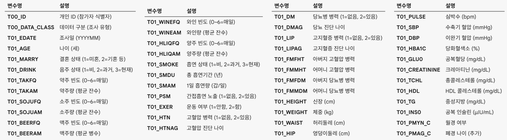

### **데이터 형태**

```python
import pandas as pd
df = pd.read_csv('/content/follow_01_data.csv')
```

```python
df
```

|  | T00_ID | T00_DATA_CLASS | T01_EDATE | T00_SEX | T01_AGE | T01_EDU | T01_MARRY | T01_DRINK | T01_DRDU | T01_TAKFQ | ... | T01_DBP | T01_HBA1C | T01_GLU0 | T01_CREATININE | T01_AST | T01_ALT | T01_TCHL | T01_HDL | T01_TG | T01_INS0 |
| --- | --- | --- | --- | --- | --- | --- | --- | --- | --- | --- | --- | --- | --- | --- | --- | --- | --- | --- | --- | --- | --- |
| 0 | K_FOLLOW_0001 | F05 | 200412 | 1 | 56 | 1 | 2 | 3 | 4 | 0 | ... | 80 | 5.6 | 82 | 0.7 | 30 | 38 | 154 | 35 | 126 | 6.7 |
| 1 | K_FOLLOW_0002 | F19 | 200401 | 1 | 40 | 3 | 2 | 3 | 4 | 0 | ... | 118 | 5.5 | 130 | 1.1 | 46 | 75 | 214 | 44 | 169 | 4.3 |
| 2 | K_FOLLOW_0003 | F05 | 200309 | 1 | 52 | 2 | 2 | 2 | 3 | 0 | ... | 90 | 5.2 | 83 | 0.9 | 29 | 45 | 130 | 27 | 134 | 7.9 |
| 3 | K_FOLLOW_0004 | F05 | 200504 | 2 | 60 | 2 | 2 | 1 | 77777 | 0 | ... | 90 | 5.6 | 89 | 0.6 | 35 | 34 | 182 | 47 | 123 | 12.6 |
| 4 | K_FOLLOW_0005 | F19 | 200402 | 1 | 49 | 3 | 2 | 3 | 4 | 0 | ... | 79 | 6.9 | 95 | 1.0 | 52 | 33 | 203 | 36 | 277 | 2.7 |
| ... | ... | ... | ... | ... | ... | ... | ... | ... | ... | ... | ... | ... | ... | ... | ... | ... | ... | ... | ... | ... | ... |
| 995 | K_FOLLOW_0996 | F05 | 200507 | 1 | 64 | 1 | 2 | 1 | 77777 | 0 | ... | 61 | 5.7 | 75 | 1.0 | 24 | 17 | 151 | 36 | 176 | 6.3 |
| 996 | K_FOLLOW_0997 | F18 | 200411 | 1 | 63 | 3 | 2 | 3 | 2 | 0 | ... | 91 | 66666.0 | 96 | 1.1 | 21 | 18 | 149 | 33 | 114 | 11.7 |
| 997 | K_FOLLOW_0998 | F19 | 200401 | 1 | 41 | 5 | 2 | 3 | 4 | 0 | ... | 65 | 5.6 | 89 | 0.9 | 23 | 26 | 273 | 36 | 83 | 8.7 |
| 998 | K_FOLLOW_0999 | F11 | 200501 | 2 | 69 | 1 | 2 | 3 | 4 | 0 | ... | 93 | 66666.0 | 88 | 0.9 | 22 | 13 | 206 | 43 | 210 | 66666.0 |
| 999 | K_FOLLOW_1000 | F19 | 200311 | 2 | 45 | 2 | 2 | 1 | 77777 | 0 | ... | 76 | 5.6 | 84 | 0.7 | 29 | 45 | 239 | 44 | 174 | 10.8 |

1000 rows × 64 columns

### **변수 선택 근거**

본 연구는 음주 여부(T01_DRINK)가 고혈압 병력(T01_HTN)에 미치는 영향을 검토하는 것을 목표로 한다. 이를 정확히 추정하기 위해서는 결과에 영향을 미칠 수 있는 잠재적 교란변수(confounders)를 적절히 통제하는 과정이 필수적이다. 따라서 고혈압과 관련성이 알려진 인구학적·생리적·대사적 요인을 기반으로 아래의 변수를 교란변수로 선정하였다.

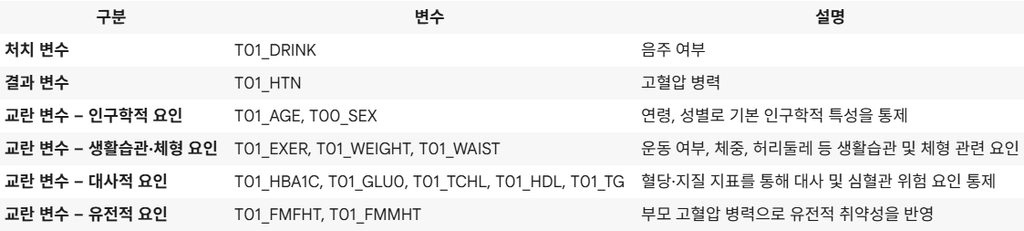

## **2. EDA(탐색적 데이터 분석)**

고혈압 여부 분포를 보면, 전체의 약 79%는 고혈압 병력이 없었으며 약 21%는 고혈압 병력이 있었다.

음주 여부는 비음주자와 음주자가 거의 비슷한 비율(49% vs 51%)로 분포하여 두 집단 규모가 균형적이다.

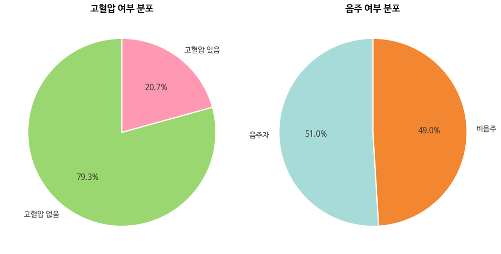

```python
# @title
# 고혈압 여부 (1=없음, 2=있음 → 0/1)
df["hypertension"] = df["T01_HTN"].map({1: 0, 2: 1})

# 음주 여부 (1=비음주, 2/3=음주자)
df["drink_binary"] = df["T01_DRINK"].map({1: "비음주", 2: "음주자", 3: "음주자"})


fig, axes = plt.subplots(1, 2, figsize=(12, 6))

# 1) 고혈압 여부
counts_htn = df["hypertension"].value_counts().sort_index()
labels_htn = ["고혈압 없음", "고혈압 있음"]
colors_htn = ["#9BD770", "#FF99B3"]

axes[0].pie(
    counts_htn,
    labels=labels_htn,
    autopct="%.1f%%",
    startangle=90,
    colors=colors_htn,
    textprops={'fontsize': 13, 'color':'#333'},
    wedgeprops={'edgecolor':'white', 'linewidth': 2}
)
axes[0].set_title("고혈압 여부 분포", fontsize=16, fontweight='bold')


# 2) 음주 여부
counts_drink = df["drink_binary"].value_counts()
colors_drink = ["#A7DBD8", "#F38630"]

axes[1].pie(
    counts_drink,
    labels=counts_drink.index,
    autopct="%.1f%%",
    startangle=90,
    colors=colors_drink,
    textprops={'fontsize': 13, 'color':'#333'},
    wedgeprops={'edgecolor':'white', 'linewidth': 2}
)
axes[1].set_title("음주 여부 분포", fontsize=16, fontweight='bold')


# 전체 제목
plt.tight_layout()
plt.show()
```

아버지와 어머니의 고혈압 병력은 각각 약 9% 수준으로 낮게 나타났다.

부모 중 한 명이라도 고혈압 병력이 있는 경우는 약 17%로 나타났다

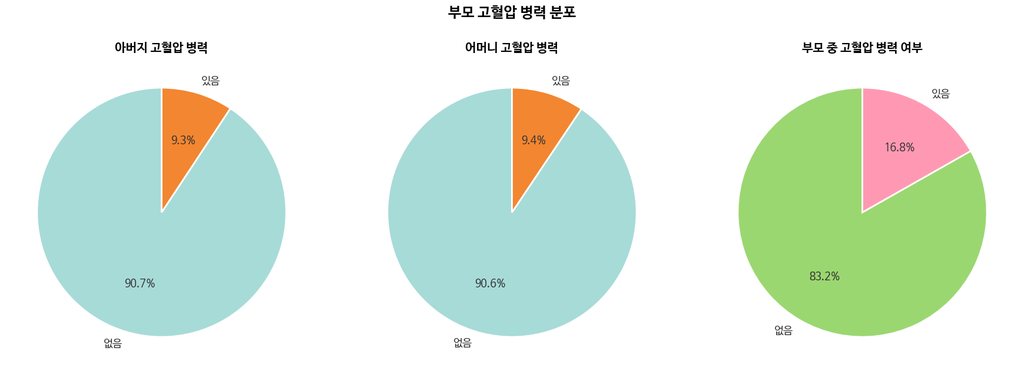

```python
# @title
df['father_htn'] = df['T01_FMFHT'].map({1: '없음', 2: '있음'})
df['mother_htn'] = df['T01_FMMHT'].map({1: '없음', 2: '있음'})

# 부모 중 한 명이라도 고혈압 (True/False → 있음/없음)
df['family_htn'] = ((df['T01_FMFHT'] == 2) | (df['T01_FMMHT'] == 2)).map({True: '있음', False: '없음'})

fig, axes = plt.subplots(1, 3, figsize=(18, 6))
titles = ["아버지 고혈압 병력", "어머니 고혈압 병력", "부모 중 고혈압 병력 여부"]
cols = ['father_htn', 'mother_htn', 'family_htn']
colors_list = [
    ["#A7DBD8", "#F38630"],     # father
    ["#A7DBD8", "#F38630"],     # mother
    ["#9BD770", "#FF99B3"]      # family
]

for i, (col, title, colors) in enumerate(zip(cols, titles, colors_list)):
    counts = df[col].value_counts()
    axes[i].pie(
        counts,
        labels=counts.index,
        autopct="%.1f%%",
        startangle=90,
        colors=colors,
        textprops={'fontsize': 13, 'color': '#333'},
        wedgeprops={'edgecolor':'white','linewidth':2}
    )
    axes[i].set_title(title, fontsize=15, fontweight='bold')

plt.suptitle("부모 고혈압 병력 분포", fontsize=18, fontweight="bold", y=1.05)
plt.tight_layout()
plt.show()
```

키 분포는 약 150–170cm 구간에 집중되어 있으며, 정규분포 형태와 유사하게 중앙에 밀집된 형태를 보인다.

몸무게 분포는 약 55–70kg 구간에 가장 많이 분포하며, 오른쪽 꼬리가 긴 약한 우측 비대칭 형태를 나타낸다. 하지만 110의 값 때문에 비대칭의 모습이 보인다 판단하였다. 110을 이상치로 판단할 수 있지만 충분히 존재할 수 있는 값이라 판단하였다

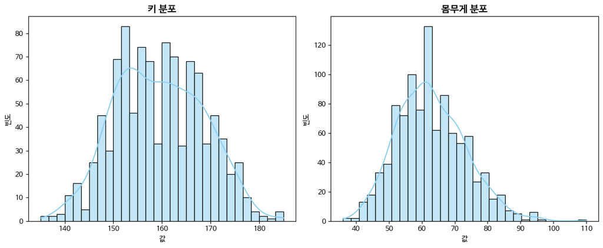

```python
# @title
import seaborn as sns

# 변수 목록
num_cols = ['T01_HEIGHT', 'T01_WEIGHT']
titles = ['키 분포', '몸무게 분포']   # ← 제목 변경

# 서브플롯 생성
fig, axes = plt.subplots(1, len(num_cols), figsize=(12, 5))

for i, col in enumerate(num_cols):
    sns.histplot(df[col], bins=30, kde=True, color='#89CFF0', ax=axes[i])
    axes[i].set_title(titles[i], fontsize=14, fontweight='bold')
    axes[i].set_xlabel('값')
    axes[i].set_ylabel('빈도')

plt.tight_layout()
plt.show()
```

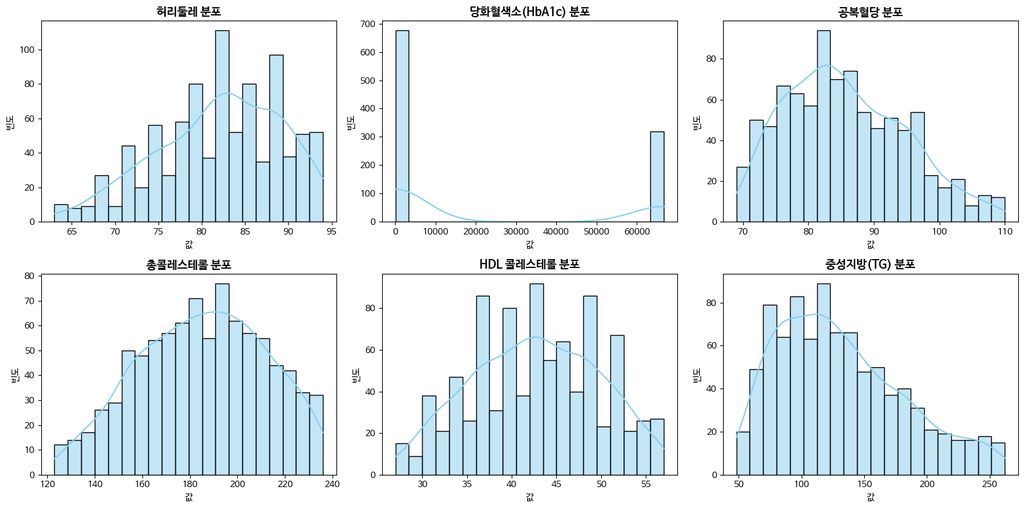

```python
# @title
# 변수 목록
num_cols = ['T01_WAIST', 'T01_HBA1C', 'T01_GLU0', 'T01_TCHL', 'T01_HDL', 'T01_TG']

# 한국어 제목 매핑
titles_kor = {
    'T01_WAIST': '허리둘레 분포',
    'T01_HBA1C': '당화혈색소(HbA1c) 분포',
    'T01_GLU0': '공복혈당 분포',
    'T01_TCHL': '총콜레스테롤 분포',
    'T01_HDL': 'HDL 콜레스테롤 분포',
    'T01_TG': '중성지방(TG) 분포'
}

# 2x3 subplot
fig, axes = plt.subplots(2, 3, figsize=(16, 8))
axes = axes.flatten()

for i, col in enumerate(num_cols):
    # 1~90 분위수 trimming
    q1, q90 = df[col].quantile([0.01, 0.90])
    data_trimmed = df[(df[col] >= q1) & (df[col] <= q90)][col]

    sns.histplot(data_trimmed, bins=20, kde=True, color='#89CFF0', ax=axes[i])
    axes[i].set_title(titles_kor[col], fontsize=13, fontweight='bold')
    axes[i].set_xlabel('값')
    axes[i].set_ylabel('빈도')


plt.tight_layout()
plt.show()
```

가족력이 있는 경우 고혈압 비율은 약 36%로, 가족력이 없는 경우(약 18%)보다 두 배가량 높게 나타났다.

운동 여부에서는 운동을 하는 집단이 약간 더 높은 고혈압 비율을 보이나, 두 집단 간 차이는 크지 않은 수준이었다.

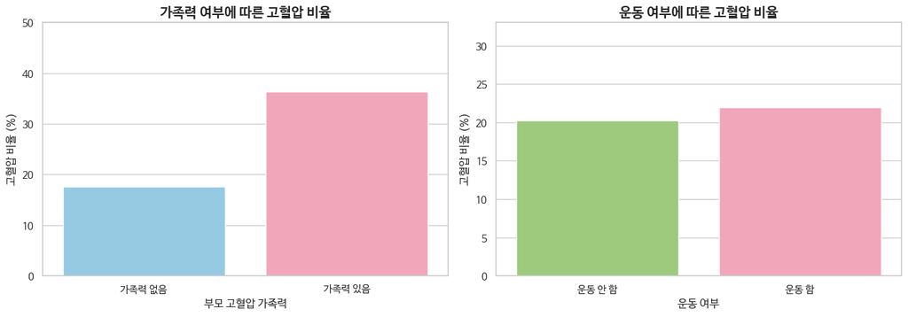

```python
# @title
import warnings
warnings.filterwarnings("ignore")


fig, axes = plt.subplots(1, 2, figsize=(14, 5))

# ───────────────────────────────────────────────────
# ① 가족력 여부에 따른 고혈압 비율
# ───────────────────────────────────────────────────
rate_family = df.groupby("family_history")["hypertension"].mean().reset_index()
rate_family["hypertension"] = rate_family["hypertension"] * 100
rate_family["family_history"] = rate_family["family_history"].map({
    0: "가족력 없음",
    1: "가족력 있음"
})

sns.barplot(
    data=rate_family,
    x="family_history",
    y="hypertension",
    palette=["#89CFF0", "#FF99B3"],
    ax=axes[0]
)

axes[0].set_title("가족력 여부에 따른 고혈압 비율", fontsize=15, fontweight='bold')
axes[0].set_xlabel("부모 고혈압 가족력")
axes[0].set_ylabel("고혈압 비율 (%)")
axes[0].set_ylim(0, 50)

# ───────────────────────────────────────────────────
# ② 운동 여부에 따른 고혈압 비율
# ───────────────────────────────────────────────────
# 운동 변수 변환
df["exercise"] = df["T01_EXER"].map({1: "운동 안 함", 2: "운동 함"})

rate_exer = df.groupby("exercise")["hypertension"].mean().reset_index()
rate_exer["hypertension"] = rate_exer["hypertension"] * 100

sns.barplot(
    data=rate_exer,
    x="exercise",
    y="hypertension",
    palette=["#9BD770", "#FF99B3"],
    ax=axes[1]
)

axes[1].set_title("운동 여부에 따른 고혈압 비율", fontsize=15, fontweight='bold')
axes[1].set_xlabel("운동 여부")
axes[1].set_ylabel("고혈압 비율 (%)")
axes[1].set_ylim(0, 33)

# 전체 레이아웃 정리
plt.tight_layout()
plt.show()
```

여성은 비음주 비율이 높고 남성은 음주자 비율이 크게 높아, 음주 행동에서 뚜렷한 성별 차이가 나타났다.

성별에 따른 고혈압에서는 여성이 약간 더 높은 고혈압 비율을 보였다.

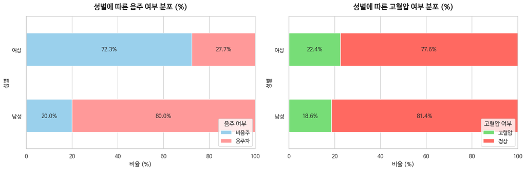

```python
# @title
fig, axes = plt.subplots(1, 2, figsize=(15, 5))


df["sex"] = df["T00_SEX"].map({1: "남성", 2: "여성"})
df["drink_group"] = df["T01_DRINK"].map({1: "비음주", 2: "음주자", 3: "음주자"})

cross1 = pd.crosstab(df['sex'], df['drink_group'], normalize='index') * 100

ax1 = cross1.plot(
    kind='barh',
    stacked=True,
    color=['#9AD0EC', '#FF9999'],  # 비음주 / 음주자
    ax=axes[0]
)

for container in ax1.containers:
    ax1.bar_label(container, fmt='%.1f%%', label_type='center', fontsize=11)

ax1.set_title("성별에 따른 음주 여부 분포 (%)", fontsize=15, fontweight='bold', pad=15)
ax1.set_xlabel("비율 (%)", fontsize=12)
ax1.set_ylabel("성별", fontsize=12)
ax1.set_xlim(0, 100)
ax1.legend(title='음주 여부', loc='lower right')



df["hypertension"] = df["T01_HTN"].map({1: "정상", 2: "고혈압"})

cross2 = pd.crosstab(df['sex'], df['hypertension'], normalize='index') * 100

ax2 = cross2.plot(
    kind='barh',
    stacked=True,
    color=['#77DD77', '#FF6961'],  # 정상 / 고혈압
    ax=axes[1]
)

for container in ax2.containers:
    ax2.bar_label(container, fmt='%.1f%%', label_type='center', fontsize=11)

ax2.set_title("성별에 따른 고혈압 여부 분포 (%)", fontsize=15, fontweight='bold', pad=15)
ax2.set_xlabel("비율 (%)", fontsize=12)
ax2.set_ylabel("성별", fontsize=12)
ax2.set_xlim(0, 100)
ax2.legend(title='고혈압 여부', loc='lower right')

plt.tight_layout()
plt.show()
```

나이별 고혈압 비율 40대 초반에서는 고혈압 비율이 5-10% 수준으로 낮지만, 나이가 증가할수록 꾸준히 상승하여 60대 후반에서는 40~50%까지 높아진다. 즉, 고혈압은 나이가 들수록 뚜렷하게 증가하는 연령 의존적 패턴을 보인다.

나이대별 음주율 음주율은 40대에서 가장 높고, 연령이 증가할수록 점진적으로 감소해 60대 후반에서 최소치를 보인다. 즉, 연령이 높아질수록 음주 비율은 낮아지는 반면 고혈압 비율은 증가하는 상반된 경향을 확인할 수 있다.

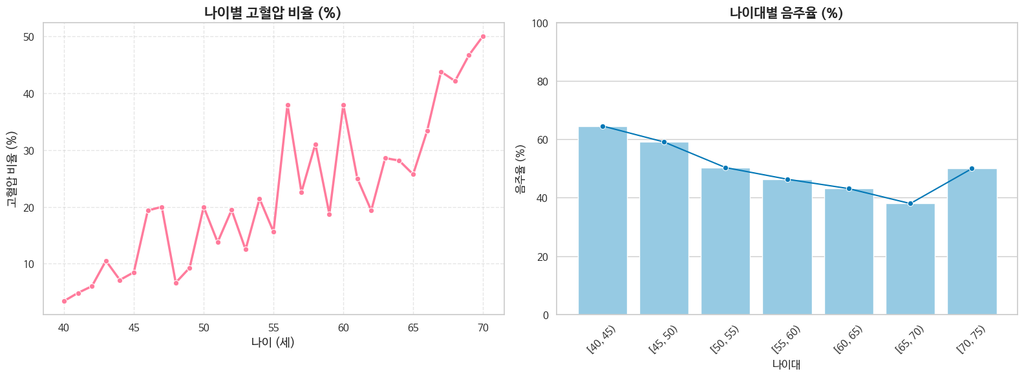

```python
# @title
fig, axes = plt.subplots(1, 2, figsize=(16, 6))


# 고혈압 변수 변환
df["hypertension"] = df["T01_HTN"].map({1: 0, 2: 1})

# 나이 필터 (40~70세)
df_age = df[(df["T01_AGE"] >= 40) & (df["T01_AGE"] <= 70)]

# 나이별 고혈압 비율
age_htn = (
    df_age.groupby("T01_AGE")["hypertension"]
    .mean()
    .reset_index()
)
age_htn["hypertension_rate"] = age_htn["hypertension"] * 100

sns.lineplot(
    data=age_htn,
    x="T01_AGE",
    y="hypertension_rate",
    color="#FF7B9C",
    linewidth=2.5,
    marker="o",
    ax=axes[0]
)

axes[0].set_title("나이별 고혈압 비율 (%)", fontsize=16, fontweight='bold')
axes[0].set_xlabel("나이 (세)", fontsize=13)
axes[0].set_ylabel("고혈압 비율 (%)", fontsize=13)
axes[0].grid(True, linestyle="--", alpha=0.5)


# 음주 변수 변환
df['drink_binary'] = df['T01_DRINK'].map({1: 0, 2: 1, 3: 1})

# 나이대 구간 (40~75세, 5년 단위)
df['age_group'] = pd.cut(df['T01_AGE'], bins=range(40, 80, 5), right=False)

drink_rate = (
    df.groupby('age_group', observed=True)['drink_binary']
    .mean()
    .reset_index()
)
drink_rate['drink_rate_percent'] = drink_rate['drink_binary'] * 100
drink_rate['age_group'] = drink_rate['age_group'].astype(str)

# 막대그래프
sns.barplot(
    data=drink_rate,
    x='age_group',
    y='drink_rate_percent',
    color='#89CFF0',
    edgecolor='white',
    ax=axes[1]
)

# 선그래프
sns.lineplot(
    data=drink_rate,
    x='age_group',
    y='drink_rate_percent',
    marker='o',
    color='#0077B6',
    ax=axes[1]
)

axes[1].set_title("나이대별 음주율 (%)", fontsize=15, fontweight='bold')
axes[1].set_xlabel("나이대")
axes[1].set_ylabel("음주율 (%)")
axes[1].set_xticklabels(drink_rate['age_group'], rotation=45)
axes[1].set_ylim(0, 100)


plt.tight_layout()
plt.show()
```

비음주자의 고혈압 비율은 약 22.8%, 음주자의 고혈압 비율은 약 18.6%로 나타났다.

두 집단의 단순 평균 차이(Naive ATE)는 약 –4.2%p로, 음주자의 고혈압 비율이 더 낮게 관찰된다.

하지만 이 값은 연령, 성별, 체중, 대사 지표 등 여러 교란변수(confounders)를 통제하지 않은 단순 비교이기 때문에, 실제 인과적 효과를 반영한다고 보기 어렵다.

즉, 음주 여부만으로 고혈압의 원인을 해석하기에는 부적절하며 추가적인 보정이 필요하다.

```
============================================================
음주 여부에 따른 고혈압 유병률 평균 비교
============================================================
비음주자 고혈압 비율 :      0.228
음주자   고혈압 비율 :      0.186
단순 평균차 (Naive ATE):     -0.042
============================================================
```

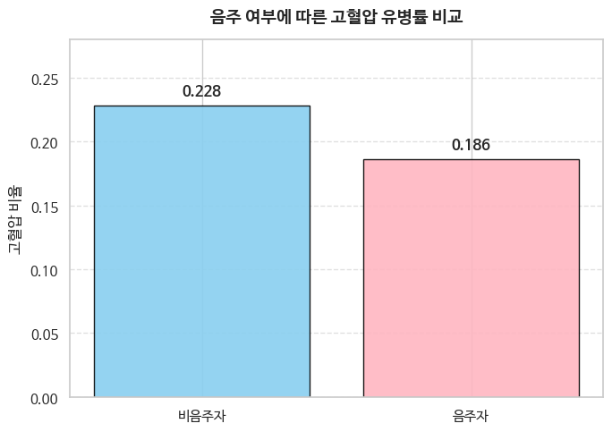

```python
# @title
treatment = 'T01_DRINK'   # 음주 여부
outcome = 'T01_HTN'       # 고혈압 병력


df['drink'] = df[treatment].map({3:1, 2:1, 1:0})


df['hypertension'] = df[outcome].map({2:1, 1:0})


df = df.dropna(subset=['drink', 'hypertension'])


mean_treated = df.loc[df['drink']==1, 'hypertension'].mean()
mean_control = df.loc[df['drink']==0, 'hypertension'].mean()
naive_ate = mean_treated - mean_control


print("="*60)
print("음주 여부에 따른 고혈압 유병률 평균 비교")
print("="*60)
print(f"비음주자 고혈압 비율 : {mean_control:>10.3f}")
print(f"음주자   고혈압 비율 : {mean_treated:>10.3f}")
print(f"단순 평균차 (Naive ATE): {naive_ate:>10.3f}")
print("="*60)



mean_treated = df.loc[df['drink']==1, 'hypertension'].mean()
mean_control = df.loc[df['drink']==0, 'hypertension'].mean()
naive_ate = mean_treated - mean_control

group_labels = ['비음주자', '음주자']
values = [mean_control, mean_treated]

colors = ['#89CFF0', '#FFB6C1']

plt.figure(figsize=(7,5))
bars = plt.bar(group_labels, values, color=colors, edgecolor='black', alpha=0.9)

for bar in bars:
    height = bar.get_height()
    plt.text(bar.get_x() + bar.get_width()/2, height + 0.005,
             f"{height:.3f}", ha='center', va='bottom', fontsize=12, fontweight='bold')

plt.title('음주 여부에 따른 고혈압 유병률 비교', fontsize=14, fontweight='bold', pad=15)
plt.ylabel('고혈압 비율', fontsize=12)
plt.ylim(0,0.28)
plt.grid(axis='y', linestyle='--', alpha=0.6)

plt.tight_layout()
plt.show()
```

# **분석방법**

본 분석에서는 음주 여부가 고혈압에 미치는 인과적 효과를 보다 정확하게 추정하기 위해 매칭(Matching) 기법을 적용하였다. 다양한 매칭 방법 중에서는, 공변량을 기반으로 처치를 받을 확률을 추정한 뒤 유사한 성향점수를 가진 개체끼리 비교하는 성향점수 매칭(Propensity Score Matching, PSM)을 사용하였다. 이를 통해 음주군과 비음주군의 기저 특성 차이를 보정하고, 보다 공정한 처치 효과 추정이 가능하도록 하였다.

### **매칭(Matching)**

매칭은 처치집단(예: 음주자)과 관찰 가능한 특성(신체적, 연령, 성별, 유전적 요인 등)이 최대한 유사한 통제집단(예: 비음주자)을 구성하여, 두 집단 간 공정하고 의미 있는 비교를 수행하기 위한 방법이다.

즉, 처치를 받은 사람과 받지 않은 사람의 사전 특성 차이를 줄여, 효과를 비교할 때 처치 자체의 영향만 남기기 위한 설계 기반 인과추론 기법이다.

그림에서도 볼 수 있듯이, 전체 모집단에서 다양한 특성을 가진 사람들 중에서 처치군과 가장 비슷한 사람들만 추려 균형 잡힌 비교 그룹을 만드는 과정이라고 이해할 수 있다.

### **성향점수 매칭 (Propensity Score Matching, PSM)**

성향점수 매칭은 전통적 매칭처럼 특성(성별, 나이 등)이 동일한 사람을 직접 매칭하는 방식이 아니라, 각 사람의 처치를 받을 확률(예: 음주할 확률)을 계산한 뒤 이 점수(Propensity Score)가 비슷한 사람들끼리 매칭하는 방법이다.

성향점수는 보통 로지스틱 회귀나 랜덤포레스트 등의 모델을 사용해 계산하며, 이 점수가 유사한 사람들끼리 짝지음으로써 처치군과 통제군의 기저 특성을 균형 있게 맞출 수 있다.

예를 들어 연령과 소득 수준이 다양한 집단에서, 처치 여부를 예측하는 성향점수를 추정한 뒤, 유사한 점수를 가진 사람들끼리 매칭하면 다차원적인 특성 차이를 한 번에 조정할 수 있다는 장점이 있다.

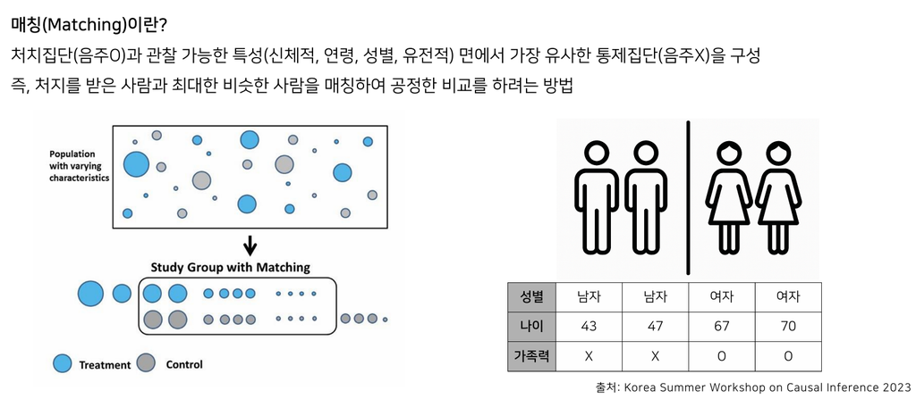

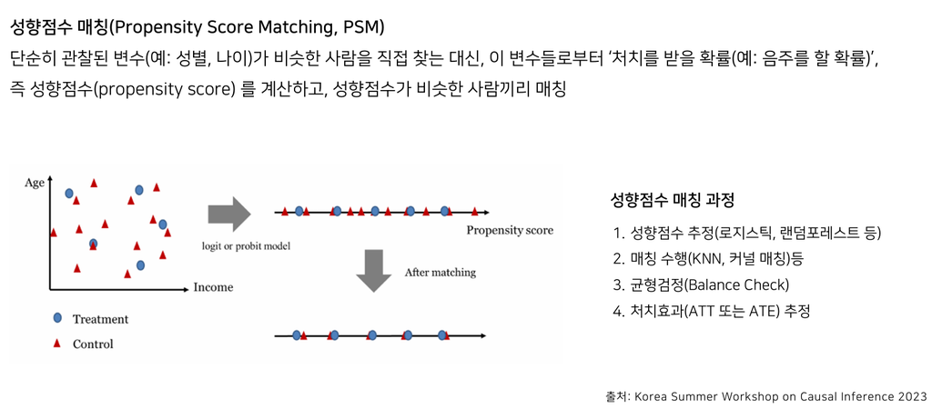

### **① 성향점수 추정 및 매칭**

로지스틱 회귀분석을 통해 공변량(성별,나이등)이 처치(음주여부)를 받을 확률을 예측하는 모형을 적합해 성향점수를 추정

이를 통해 성향점수는 0~1사이의 확률값으로 산출,점수의 의미는 처치를 받을 확률(음주를할확률)

매칭은 KNN 기반의 최근접 매칭(nearest neighbor matching)을 사용하였으며, 단일 매칭을 위해 k=1로 설정하여 각 처치군 개체와 성향점수가 가장 유사한 통제군 개체를 1:1로 대응시켰다.

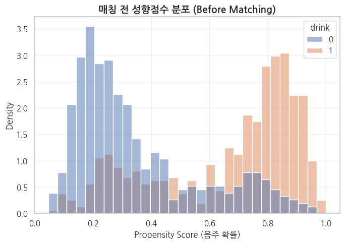

```python
import numpy as np
from sklearn.linear_model import LogisticRegression
from sklearn.neighbors import NearestNeighbors
warnings.filterwarnings("ignore")

plt.rc('font', family='NanumGothic')

# -----------------------------
# 변수 설정
# -----------------------------
treatment = 'T01_DRINK'   # 음주 여부
outcome = 'T01_HTN'       # 고혈압 병력

# 흡연 때와 동일한 구조로 변수 생성
df['drink'] = df[treatment].map({3:1, 2:1, 1:0})   # 1=비음주, 2·3=음주
df['hypertension'] = df[outcome].map({2:1, 1:0})   # 1=없음, 2=있음

# -----------------------------
# 교란변수 목록
# -----------------------------
covariates = [
    'T01_AGE', 'T00_SEX', 'T01_EXER',
    'T01_WEIGHT', 'T01_WAIST',
    'T01_HBA1C', 'T01_GLU0', 'T01_TCHL', 'T01_HDL', 'T01_TG',
    'T01_FMFHT', 'T01_FMMHT'
]

# -----------------------------
# 결측값 제거
# -----------------------------
df = df.replace([np.inf, -np.inf], np.nan).dropna(subset=['drink', 'hypertension'] + covariates)

# -----------------------------
# 4Propensity Score (성향점수) 추정
# -----------------------------
X = df[covariates]
T = df['drink']
Y = df['hypertension']

ps_model = LogisticRegression(max_iter=1000)
ps_model.fit(X, T)
df['propensity_score'] = ps_model.predict_proba(X)[:, 1]

# -----------------------------
# 51:1 최근접 매칭 (Nearest Neighbor)
# -----------------------------
treated = df[df['drink'] == 1]
control = df[df['drink'] == 0]

nn = NearestNeighbors(n_neighbors=1)
nn.fit(control[['propensity_score']])
distances, indices = nn.kneighbors(treated[['propensity_score']])

matched_control = control.iloc[indices.flatten()]
matched_df = pd.concat([treated, matched_control])

plt.figure(figsize=(7,5))

sns.histplot(
    data=df,
    x="propensity_score",
    hue="drink",
    bins=30,
    alpha=0.5,
    stat='density',
    common_norm=False
)

plt.title("매칭 전 성향점수 분포 (Before Matching)", fontsize=14, fontweight='bold')
plt.xlabel("Propensity Score (음주 확률)")
plt.ylabel("Density")
plt.grid(alpha=0.3)

plt.tight_layout()
plt.show()
```

### **② 균형점검**

성향점수매칭(PSM)의 적절성을 평가하기 위해 매칭 전후 성향점수 분포를 비교하여 균형을 점검하였다.

매칭 이전에는 음주자와 비음주자 간의 성향점수 분포가 뚜렷하게 달라 두 집단이 체계적으로 차이가 나는 것으로 나타났다.

매칭 이후에는 두 집단의 분포가 거의 동일한 형태로 수렴하여, 매칭이 적절히 수행된 것을 확인하였다

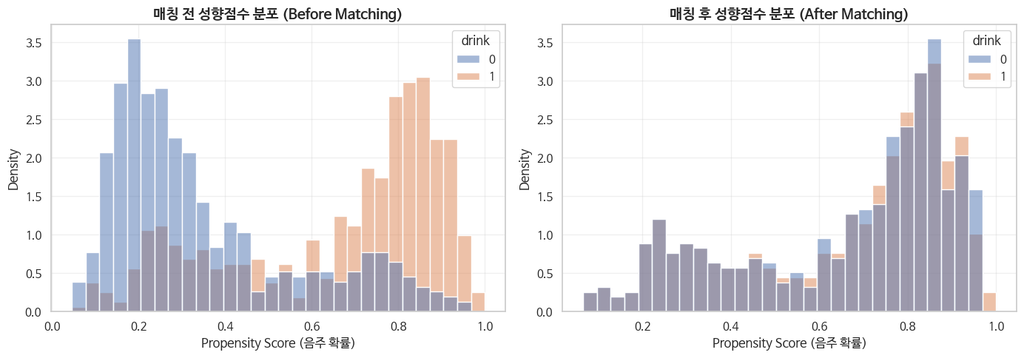

```python
# @title
treated = df[df['drink'] == 1].copy()
control = df[df['drink'] == 0].copy()

matched_treated = treated.copy()
matched_control = matched_control.copy()
matched_all = pd.concat([matched_treated, matched_control])


fig, axes = plt.subplots(1, 2, figsize=(14, 5))

# 1매칭 전 성향점수 분포
sns.histplot(
    data=df,
    x="propensity_score",
    hue="drink",
    bins=30,
    alpha=0.5,
    stat='density',
    common_norm=False,
    ax=axes[0]
)
axes[0].set_title("매칭 전 성향점수 분포 (Before Matching)", fontsize=14, fontweight='bold')
axes[0].set_xlabel("Propensity Score (음주 확률)")
axes[0].set_ylabel("Density")

# 2매칭 후 성향점수 분포
sns.histplot(
    data=matched_all,
    x='propensity_score',
    hue='drink',
    bins=30,
    alpha=0.5,
    stat='density',
    common_norm=False,
    ax=axes[1]
)
axes[1].set_title("매칭 후 성향점수 분포 (After Matching)", fontsize=14, fontweight='bold')
axes[1].set_xlabel("Propensity Score (음주 확률)")
axes[1].set_ylabel("Density")

# 공통 스타일
for ax in axes:
    ax.grid(alpha=0.3)

plt.tight_layout()
plt.show()
```

Love Plot은 성향점수 매칭(PSM)에서 ‘매칭 전후 공변량 균형(covariate balance)’을 시각적으로 확인하기 위한 그래프이다.

각 공변량에 대해 표준화 평균차이(Standardized Mean Difference, SMD) 를 계산한 후, 매칭 전(Unadjusted)과 매칭 후(Adjusted)의 값을 나란히 비교함으로써 두 집단(처치군 vs 대조군)이 얼마나 유사해졌는지를 직관적으로 평가하는 데 사용된다.

왼쪽 그래프는 SMD의 부호(+/-)까지 반영하여 어떤 집단에서 평균이 더 높은지 차이가 어느 정도인지 를 보여준다.

여러 공변량에서 SMD 값이 0.2–1.2 수준까지 커서, 처치군(음주자)과 대조군(비음주자)이 처음부터 매우 다른 집단이었음을 의미한다.

→ 즉, 매칭 전에는 교란이 상당히 존재했다는 뜻이다.

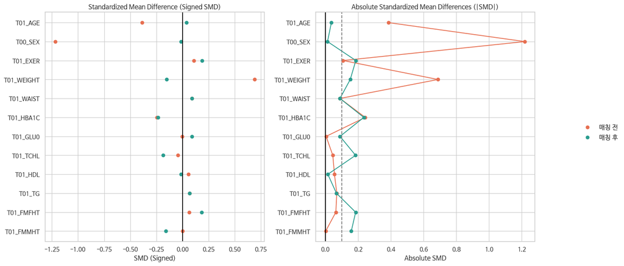

```python
# @title
# -------------------------------
# 공통 설정 (변수 목록)
# -------------------------------
covs = [
    "T01_AGE", "T00_SEX", "T01_EXER", "T01_WEIGHT", "T01_WAIST",
    "T01_HBA1C", "T01_GLU0", "T01_TCHL", "T01_HDL", "T01_TG",
    "T01_FMFHT", "T01_FMMHT"
]

# -------------------------------
# SMD 계산 함수
# -------------------------------
def smd_signed(x1, x0):
    return (x1.mean() - x0.mean()) / np.sqrt((x1.var() + x0.var()) / 2)

def smd_abs(x1, x0):
    return abs(x1.mean() - x0.mean()) / np.sqrt((x1.var() + x0.var()) / 2)

before_signed, after_signed = [], []
before_abs, after_abs = [], []

for cov in covs:
    before_signed.append(smd_signed(df[df.drink==1][cov], df[df.drink==0][cov]))
    after_signed.append(smd_signed(matched_all[matched_all.drink==1][cov],
                                   matched_all[matched_all.drink==0][cov]))

    before_abs.append(smd_abs(df[df.drink==1][cov], df[df.drink==0][cov]))
    after_abs.append(smd_abs(matched_all[matched_all.drink==1][cov],
                             matched_all[matched_all.drink==0][cov]))


# -------------------------------
# 1행 2열 그래프
# -------------------------------
fig, axes = plt.subplots(1, 2, figsize=(14, 7))
y = np.arange(len(covs))

# 공통 색상
color_before = "#E76F51"   # Red-Orange
color_after  = "#2A9D8F"   # Teal-Green

# ==========================================
# ① 왼쪽 그래프: 부호 있는 SMD
# ==========================================
axes[0].plot(before_signed, y, 'o', color=color_before)
axes[0].plot(after_signed, y, 'o', color=color_after)

axes[0].axvline(0, color='black', linestyle='-')

axes[0].set_yticks(y)
axes[0].set_yticklabels(covs)
axes[0].set_title("Standardized Mean Difference (Signed SMD)")
axes[0].set_xlabel("SMD (Signed)")
axes[0].invert_yaxis()


# ==========================================
# ② 오른쪽 그래프: 절댓값 SMD (Threshold 포함)
# ==========================================
axes[1].plot(before_abs, y, 'o-', color=color_before)
axes[1].plot(after_abs, y, 'o-', color=color_after)

# 추가 요청: threshold line + 0 기준선
axes[1].axvline(0, color='black', linestyle='-')
axes[1].axvline(0.1, color='gray', linestyle='--')

axes[1].set_yticks(y)
axes[1].set_yticklabels(covs)
axes[1].set_title("Absolute Standardized Mean Differences (|SMD|)")
axes[1].set_xlabel("Absolute SMD")
axes[1].invert_yaxis()


fig.legend(
    ["매칭 전", "매칭 후"],
    loc="center right",
    bbox_to_anchor=(1.15, 0.5),
    fontsize=12,
    frameon=False
)

plt.tight_layout()
plt.show()
```

### **② ATE(Average Treatment Effect, 평균 처치 효과) 추정**

매칭 후 매칭된 각 쌍(음주O 사람, 음주X 사람)의 결과 차이의 평균을 구해 ATE(평균처치효과)추정

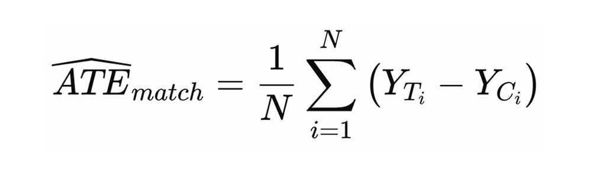

```python
ate_psm = (
    matched_df[matched_df['drink']==1]['hypertension'].mean()
    - matched_df[matched_df['drink']==0]['hypertension'].mean()
)

print("="*60)
print("Propensity Score Matching (PSM) 결과")
print("="*60)
print(f"매칭 후 샘플 수: {len(matched_df)} (처치:{len(treated)}, 대조:{len(matched_control)})")
print(f"PSM 기반 추정 ATE (음주 → 고혈압): {ate_psm:>10.4f}")
print("="*60)
```

```
============================================================
Propensity Score Matching (PSM) 결과
============================================================
매칭 후 샘플 수: 1012 (처치:506, 대조:506)
PSM 기반 추정 ATE (음주 → 고혈압):     0.0474
============================================================
```

이는 초기의 단순 비교 결과가 연령, 성별, 생활습관, 대사지표 등과 같은 잠재적 교란에 의해 왜곡되었음을 의미하며, 교란을 제거한 후에는 음주가 실제로 고혈압 위험요인으로 작용할 가능성이 높다는 점을 시사한다.

### **Bootstrap을** **사용한 분산 추정 및 신뢰구간 추정**

부트스트랩으로 재추정한 평균도 거의 동일한 값(4.7%p).

추정의 일관성이 높다는 것을 의미

신뢰구간 하한(약 0.0004)이 0을 초과함 → 0을 포함하지 않음

음주가 고혈압 발생률에 미치는 효과가 통계적으로 유의함

즉, 단순히 우연으로 나타난 차이가 아니라 실제 효과가 존재할 가능성이 높음

```python
import numpy as np

def bootstrap_se_matched_ate(matched_df, B=1000):
    ates = []
    n = len(matched_df)

    for _ in range(B):
        sample = matched_df.sample(n, replace=True)
        ate_b = (
            sample[sample['drink']==1]['hypertension'].mean()
            - sample[sample['drink']==0]['hypertension'].mean()
        )
        ates.append(ate_b)

    ates = np.array(ates)
    se = ates.std(ddof=1)

    return se, np.mean(ates)

# 실행
se_matched, ate_boot_mean = bootstrap_se_matched_ate(matched_df, B=1000)

print("ATE (Matched diff):", ate_psm)
print("Bootstrap 평균:", ate_boot_mean)
print("Bootstrap 표준오차(SE):", se_matched)
```

```
ATE (Matched diff): 0.047430830039525695
Bootstrap 평균: 0.04708413405320972
Bootstrap 표준오차(SE): 0.023796537974442544
```

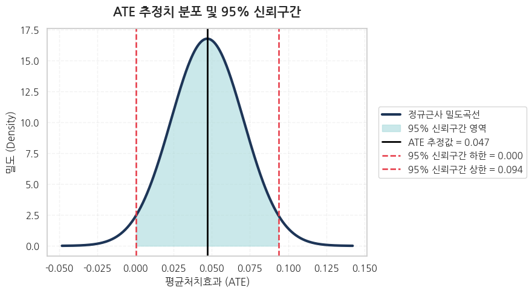

```python
# @title
import numpy as np
import matplotlib.pyplot as plt

mean_ate = 0.04708413405320972
se = 0.023796537974442544

# -----------------------------
# Normal Approximation Curve
# -----------------------------
x = np.linspace(mean_ate - 4*se, mean_ate + 4*se, 400)
y = (1 / (se * np.sqrt(2 * np.pi))) * np.exp(-0.5 * ((x - mean_ate) / se)**2)

# 95% CI
ci_lower = mean_ate - 1.96 * se
ci_upper = mean_ate + 1.96 * se

# -----------------------------
# Plot Style
# -----------------------------
plt.figure(figsize=(9, 5))

# 밀도 곡선
plt.plot(
    x, y,
    color="#1D3557", linewidth=3,
    label="정규근사 밀도곡선"
)

# 신뢰구간 음영
plt.fill_between(
    x, y,
    where=(x >= ci_lower) & (x <= ci_upper),
    color="#A8DADC", alpha=0.6,
    label="95% 신뢰구간 영역"
)

# ATE 평균선
plt.axvline(
    mean_ate, color="#000000",
    linewidth=2, linestyle="-",
    label=f"ATE 추정값 = {mean_ate:.3f}"
)

# 신뢰구간 경계
plt.axvline(
    ci_lower, color="#E63946",
    linestyle="--", linewidth=1.8,
    label=f"95% 신뢰구간 하한 = {ci_lower:.3f}"
)
plt.axvline(
    ci_upper, color="#E63946",
    linestyle="--", linewidth=1.8,
    label=f"95% 신뢰구간 상한 = {ci_upper:.3f}"
)

# -----------------------------
# Labels & Title
# -----------------------------
plt.title(
    "ATE 추정치 분포 및 95% 신뢰구간",
    fontsize=15, fontweight='bold',
    pad=15
)
plt.xlabel("평균처치효과 (ATE)", fontsize=12)
plt.ylabel("밀도 (Density)", fontsize=12)
plt.grid(alpha=0.25, linestyle="--")

# 범례를 그래프 밖으로 이동
plt.legend(
    loc="center left",
    bbox_to_anchor=(1.02, 0.5),
    frameon=True
)

plt.tight_layout()
plt.show()
```

# **결론**

본 연구에서는 성향점수매칭(PSM)을 활용해 음주가 고혈압에 미치는 인과적 영향을 추정하였다.

이는 교란변수로 인해 왜곡되었던 효과가 보정 후 올바르게 드러났음을 의미하며, 음주가 실제로 고혈압 위험을 증가시킬 가능성을 시사한다.